# Labour Market Equilibrium

Labour Economics, ECON207 — UG-II, 2026: Semester IV

Ravikiran Naik

Department of Economics, FLAME University

March 2026

**Labour Market Equilibrium**

> *“Order is not pressure which is imposed on society from without, but an equilibrium which is set up from within”*

> **— Jose Ortega y Gasset**

## How Do Labour Markets Coordinate Workers & Firms?

- **Equilibrium** coordinates firms and workers, determining the wage and employment level.
- Two polar market types: **monopsony** (one buyer) and **monopoly** (one seller of labour).
- Competitive equilibrium occurs when **supply equals demand** at a single wage.
- Markets are always *moving toward* equilibrium, even if they never fully arrive.

## What Does Pareto Efficiency Mean?

- **Pareto efficiency**: all possible gains from trade have been exhausted.
- A **Pareto-improving** change makes someone better off without harming anyone else.
- The **First Welfare Theorem** guarantees that competitive equilibria are Pareto efficient — but efficiency says **nothing** about fairness.
- Most real policies create winners and losers; economists use the **Kaldor-Hicks** criterion: a change is efficient if winners *could* compensate losers.

## How Does Competitive Equilibrium Work?

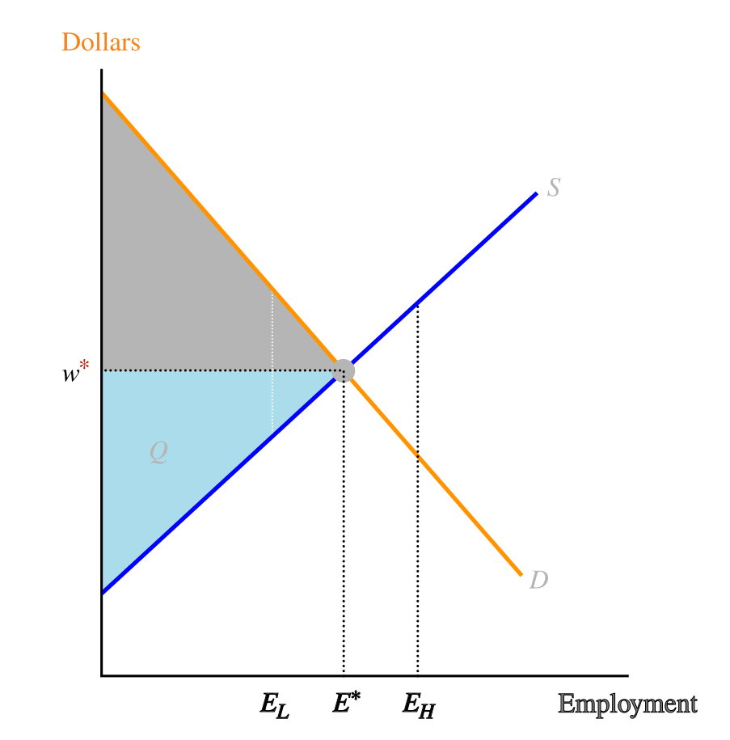

## Why One Wage → Efficiency?

- With **perfect mobility**, workers migrate until a single wage prevails everywhere.
- The **invisible hand**: self-interested decisions produce allocative efficiency.
- In equilibrium, **wage = VMP** everywhere; migration eliminates regional differentials.
- Equalising VMP across markets produces an **efficient allocation** of labour resources.

## What Happens When Workers Migrate Between Regions?

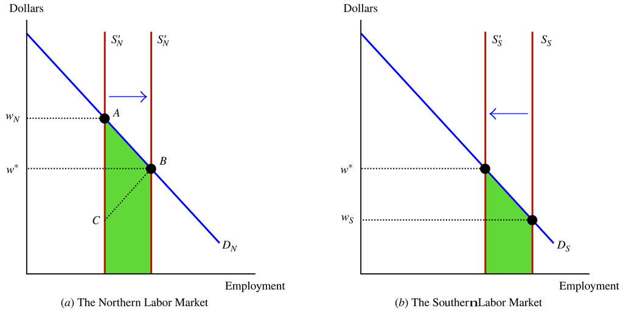

## Do State Wages Converge Over Time?

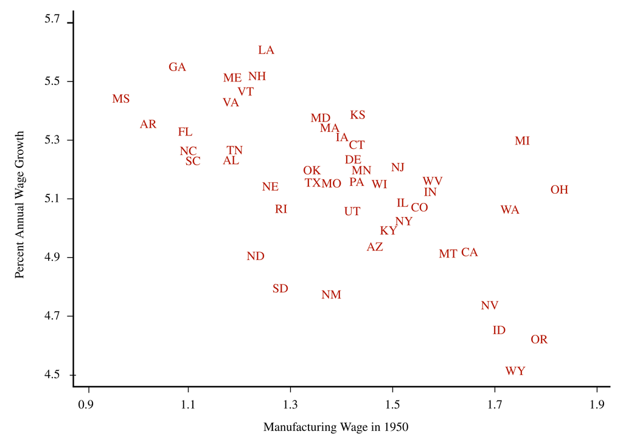

**Payroll Taxes**

[figure not shown]

> *“In this world, nothing is certain except death and taxes.”*

> **— Benjamin Franklin**

## What Happens When Firms Must Pay a Payroll Tax?

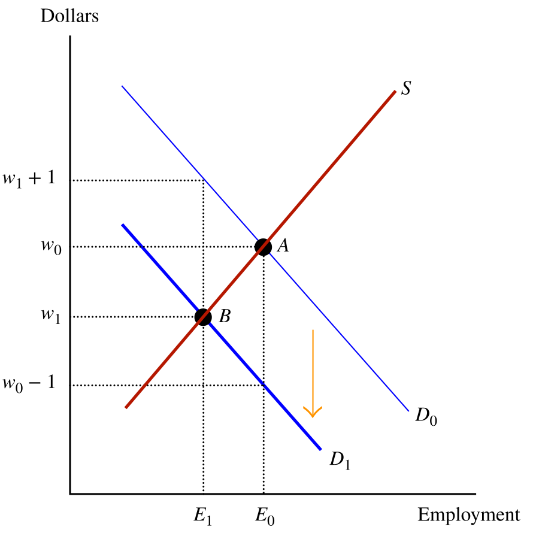

## Does It Matter Who Pays the Payroll Tax?

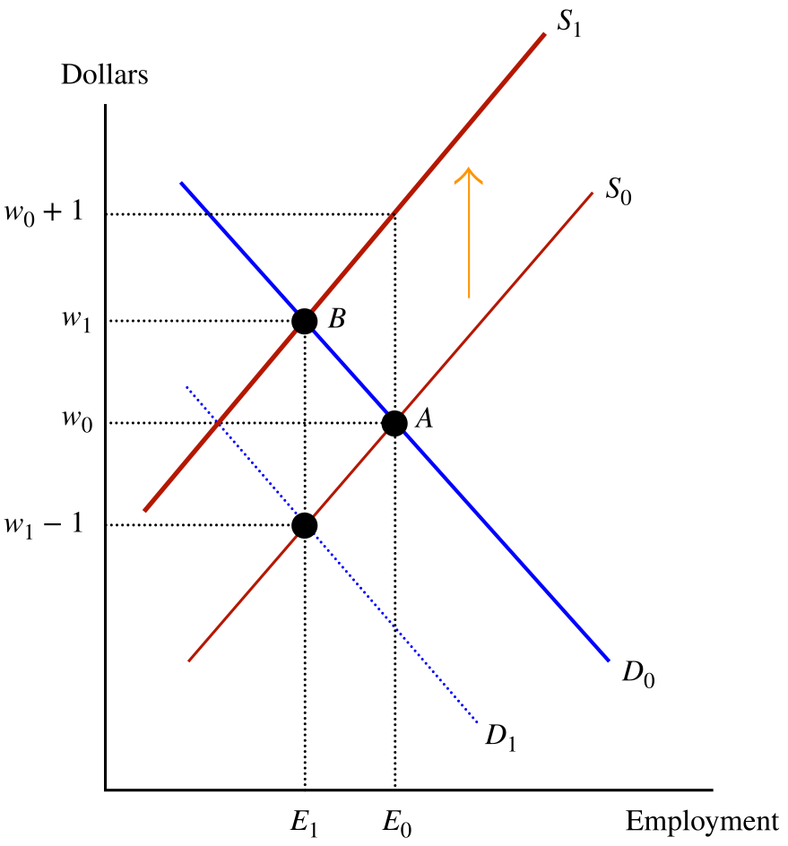

## Tax w/ Perfectly Inelastic L Supply

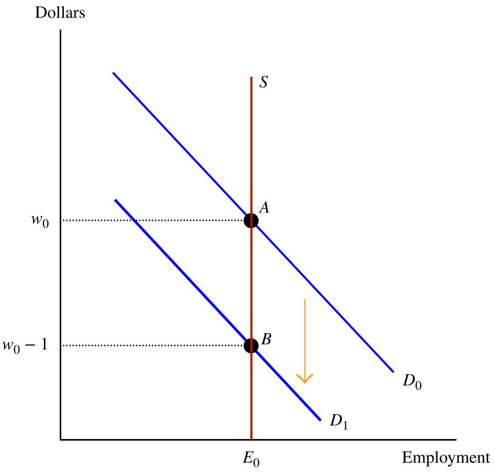

## How Much Does Society Lose from a Payroll Tax?

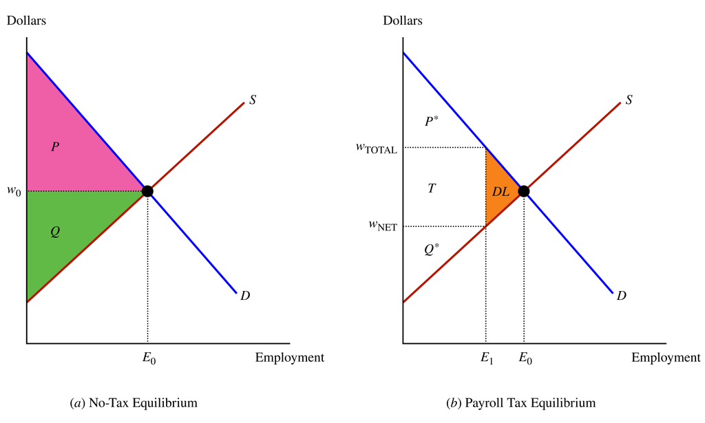

## How Does an Employment Subsidy Affect Wages & Jobs?

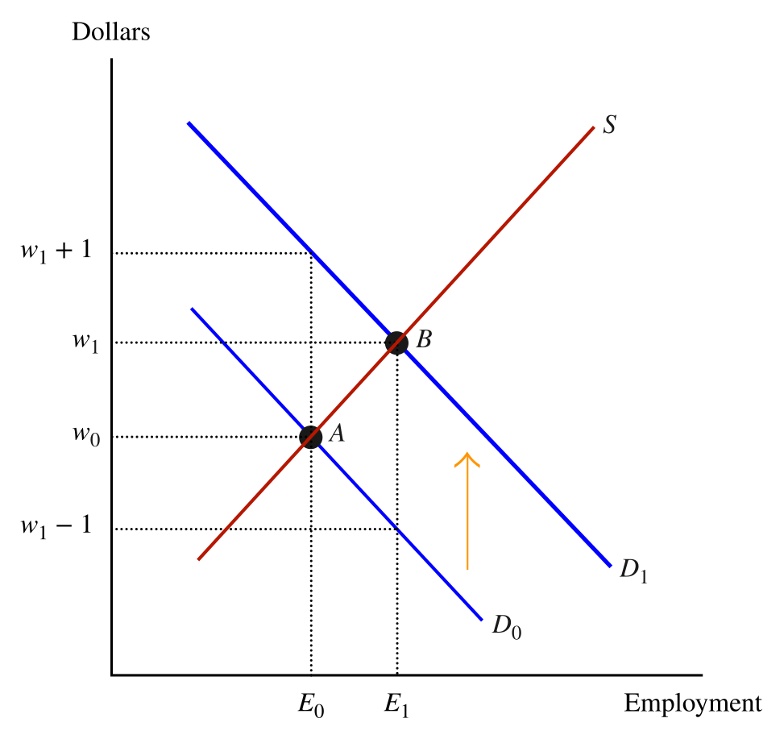

**Immigration**

> *“Everywhere immigrants have enriched and strengthened the fabric of American life.”*

> **— John F. Kennedy**

## How Does Immigration Shift the Labour Market?

- Immigration shifts labour supply to the **right**, increasing total employment.
- Equilibrium wage **decreases** as more workers compete for jobs.

## How Does Immigration Affect Native-Born Workers?

- **Competing** natives face lower wages; **complementary** natives earn higher wages.
- Natives can offset losses by **specialising** in tasks suited to their skills (Peri & Sparber, 2009).
- The **elasticity of substitution** ($\sigma$) determines the degree: $\sigma = \infty$ for perfect substitutes, $\sigma = 0$ for perfect complements.
- Whether immigration helps or hurts native workers is ultimately an **empirical question** — the answer varies by skill group and time horizon.

## If Immigrants & Natives Are Perfect Substitutes

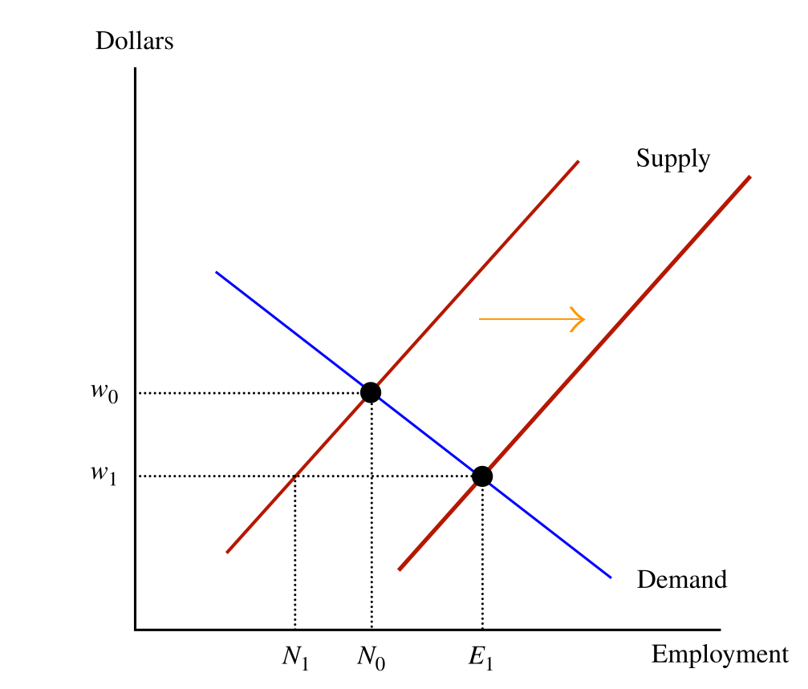

## What If Immigrants & Natives Are Complements?

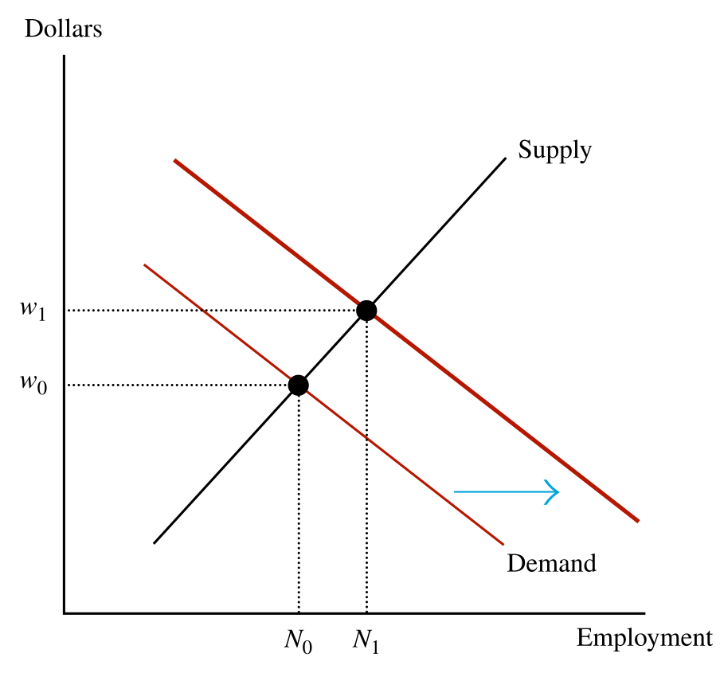

## Immigration Effects in the Long Run

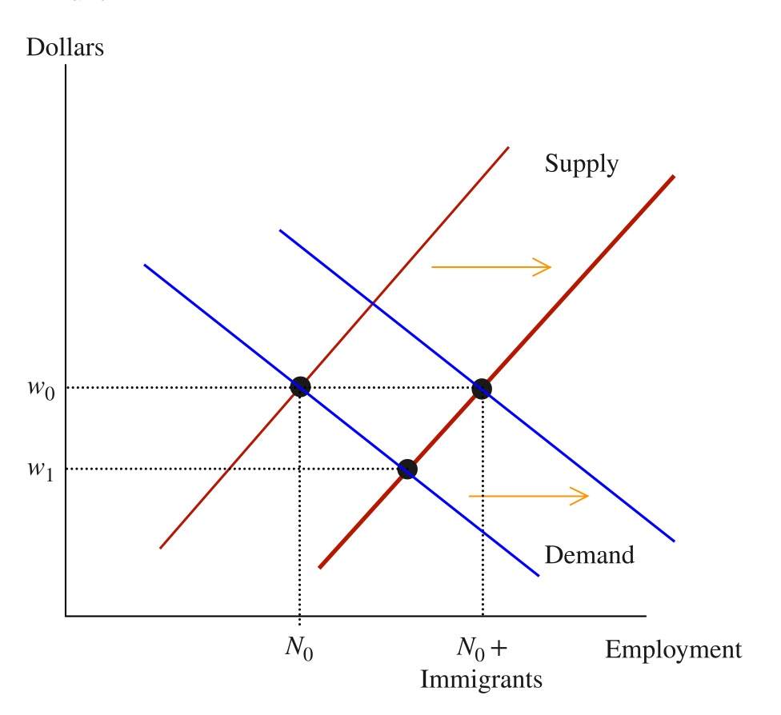

## Does Immigration Depress Similar Natives’ Wages?

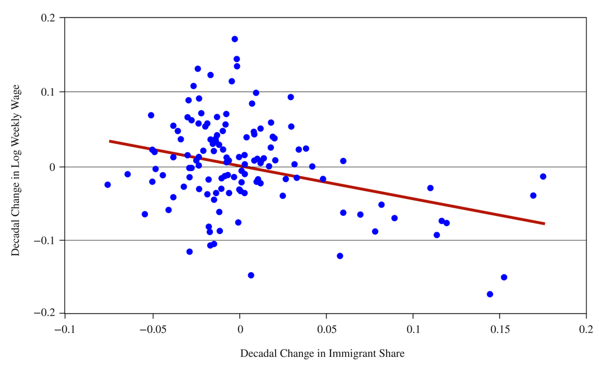

## Positive Externalities & Immigration Surplus

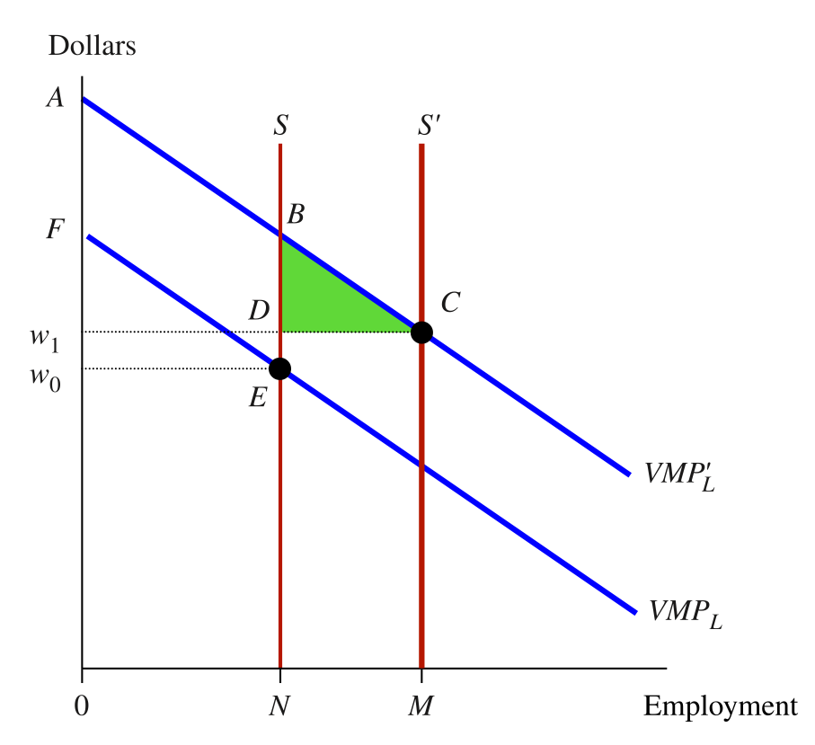

**Monopsony**

> *“Labour is not a commodity.”*

> **— Declaration of Philadelphia, ILO (1944)**

## What Happens When Only One Firm Buys Labour?

- **Monopsony**: a single firm is the only buyer of labour in the market.
- The monopsonist faces an **upward-sloping** supply curve — to hire more, it must raise wages.
- Two types: **perfectly discriminating** (pays each worker a different wage) and **nondiscriminating** (pays all the same wage).
- Even with multiple employers, **search frictions** can give firms monopsony-like wage-setting power (Manning, 2003).

## The Discriminating Monopsonist’s Hiring Rule

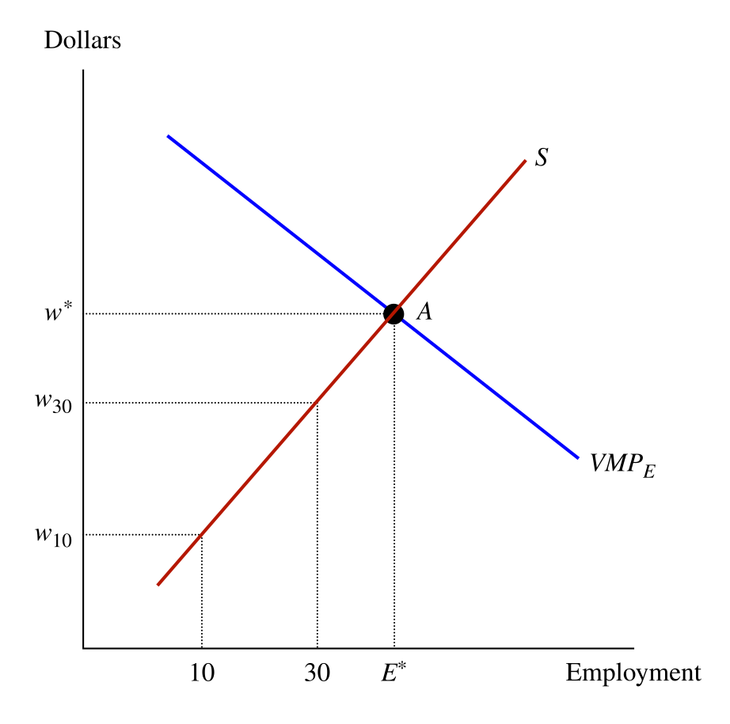

## The Nondiscriminating Monopsonist’s Hiring Rule

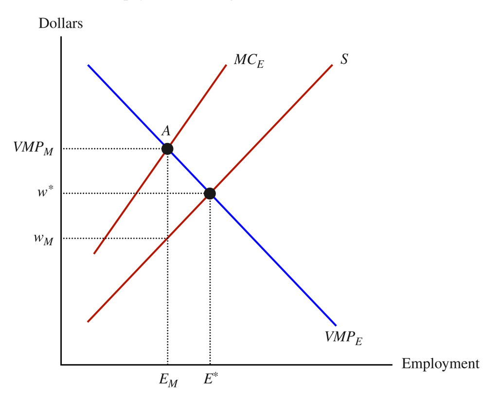

## Can a Minimum Wage Increase Employment?

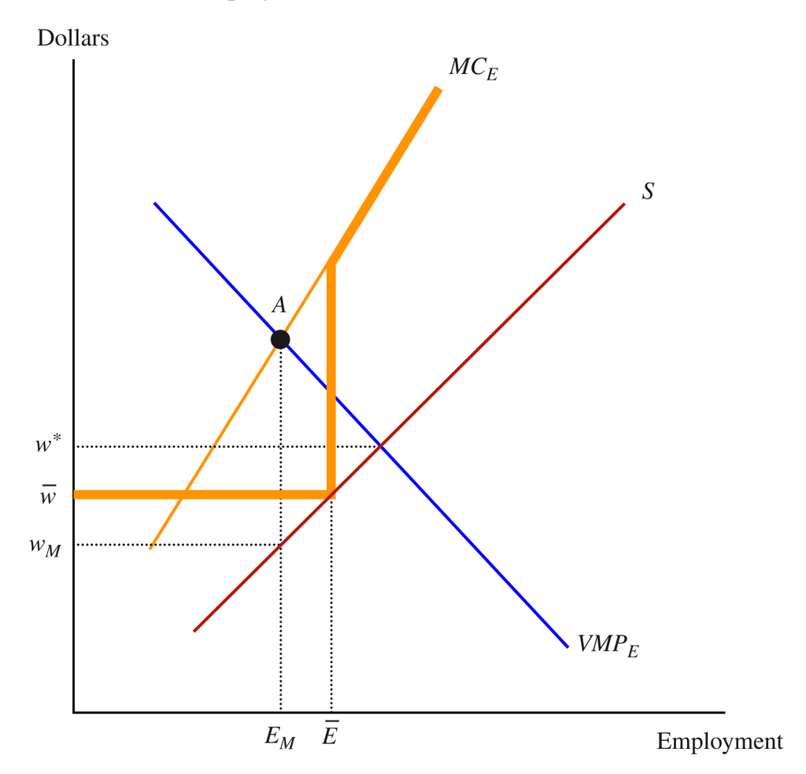

**Determinants of Supply & Demand**

> *“The curious task of economics is to demonstrate to men how little they really know about what they imagine they can design.”*

> **— F.A. Hayek**

## What Factors Shift the Labour Supply Curve?

- **Wages in other occupations**: higher outside wages reduce supply to this market (opportunity cost).
- **Nonwage income**: wealth, spouse’s earnings, or government transfers reduce labour supply (income effect).
- **Preferences** for work versus leisure and cultural attitudes toward employment shift supply.
- **Demographics**: population size, immigration, and the number of qualified workers determine the supply base.

## What Factors Shift the Labour Demand Curve?

- **Product demand**: higher output prices raise MRP, shifting labour demand right.
- **Productivity and technology**: innovations can raise or lower demand depending on whether labour is complemented or replaced.
- **Prices of other inputs**: whether capital and labour are gross substitutes or complements determines the direction.
- **Number of employers**: more firms competing for workers increases aggregate demand.

**Chapter Review**

> *“The only way to learn mathematics is to do mathematics.”*

> **— Paul Halmos**

## Review — Benefits, Immigration & Monopsony

1. Mandated benefits reduce employment unless workers fully value them.
2. Immigration shifts supply right; complements gain, substitutes lose.
3. Long run: capital adjusts, restoring wages; high-skill immigrants lift native pay.
4. Monopsony: wage-setting power → fewer workers hired at lower wages.
5. A minimum wage can *increase* employment under monopsony — the opposite of competitive predictions.

## What Is the Key Takeaway?

Questions?

> *“When everything is easy one quickly gets stupid.”*

> **— Maxim Gorky**